# Monday, September 28th, 2026

Last week, we started using `matplotlib.pyplot` to plot data. We were considering a function `y(t,y0,g,v0)` that returned the height at time `t` of an object in freefall with initial height `y0`, initial velocity `v0`, and constant of acceleration `g`.

```python
def y(t,y0,v0=0,g=-9.8):
    return (g/2)*t**2 + v0*t + y0
```

To get started with plotting, we import `matplotlib.pyplot` and typically assign it the name `plt`.

```python
import matplotlib.pyplot as plt
```

We finished last class by plotting two curves: One showing the height vs time of an object in freefall from rest at an initial height of $1000$m on Earth, and the other the same but for an object on Mars.

```python
y0 = 1000      # Initial height
g_Earth = -9.8 # Gravitational constant on Earth
g_Mars = -3.7  # Gravitational constant on Mars

t_list = [t for t in range(17)]
y_Earth_list = [y(t, y0, g=g_Earth) for t in t_list]
y_Mars_list = [y(t, y0, g=g_Mars) for t in t_list]
```

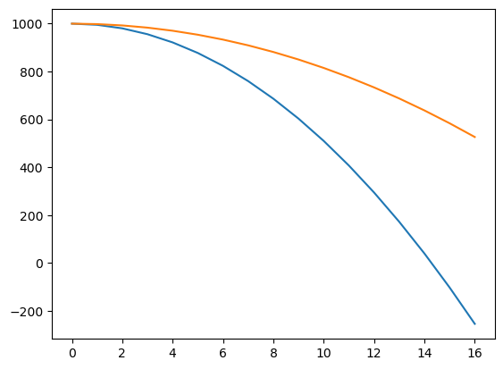

```python
plt.plot(t_list, y_Earth_list)
plt.plot(t_list, y_Mars_list)
```

## Customizing `matpotlib` plots

By default, the `plot` function will connect the supplied data points with a polygonal line, with the color selected automatically. We can include additional keyword arguments to change this behavior.

### Changing the color

For example, the keyword argument `color` can be used to manually set the color. There are many color characters available:

- `'r'`: red
- `'g'`: green
- `'b'`: blue
- `'k'`: black
- `'m'`: magenta
- `'c'`: cyan
- `'y'`: yellow
- `'C0'`, `'C1'`, ... `'C9'`: a sequence of colors that `pyplot` automatically uses when no color is supplied

We can also supply certain color names (see [Matplotlib documentation](https://matplotlib.org/stable/gallery/color/named_colors.html)), or an RGB triple of integers (we will discuss this later in the course).

**Exercise:** Replicate the previous plot, then modify the code so that the path of the object on Earth is plotted in blue and the path of the object on Mars is plotted in red.

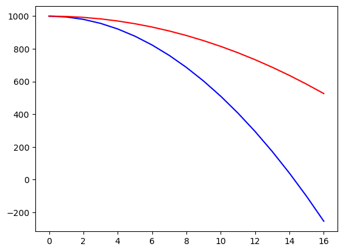

```python
plt.plot(t_list, y_Earth_list, color='b')
plt.plot(t_list, y_Mars_list, color='r')
```

### Changing the marker style

The keyword argument `marker` can be used to change the marker style. Here are some of the available styles:

- `'.'`: point
- `','`: pixel
- `'o'`: circle
- `'^'`: triangle
- `'*'`: star
- `'s'`: square
- `'+'`: plus
- `'x'`: x

More can be found in the [Matplotlib documentation](https://matplotlib.org/stable/api/markers_api.html).

**Exercise:** Replicate the previous plot, then modify the code so that the Earth path uses triangle markers and the Mars path uses square markers.

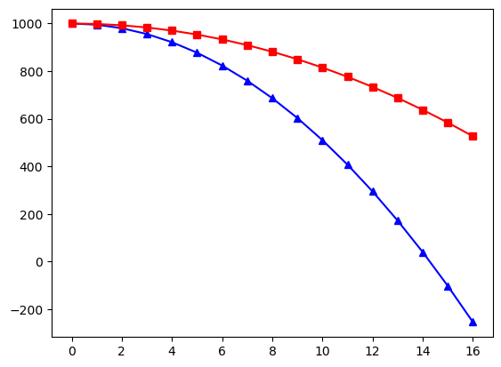

```python
plt.plot(t_list, y_Earth_list, color='b', marker='^')
plt.plot(t_list, y_Mars_list, color='r', marker='s')
```

### Changing the line style

The keyword argument `linestyle` can be used to change the line style. Here are some of the available styles:

- `'-'` or `'solid'`: solid line
- `'--'` or `'dashed'`: dashed line
- `':'` or `'dotted'`: dotted line
- `'-.'` or `'dashdot`': alternating dots and dashes
- `''` or `'None'`: no line

More can be found in the [Matplotlib documentation](https://matplotlib.org/stable/gallery/lines_bars_and_markers/linestyles.html).

**Exercise:** Replicate the previous plot, then modify the code so that the Earth path uses a dashed line and the Mars path uses a dotted line.

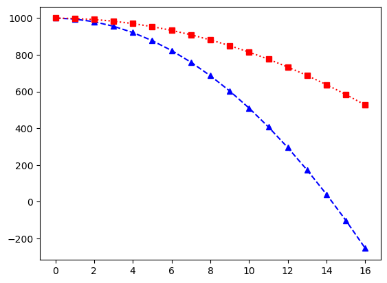

```python
plt.plot(t_list, y_Earth_list, color='b', marker='^', linestyle='--')
plt.plot(t_list, y_Mars_list, color='r', marker='s', linestyle=':')
```

### Using the `fmt` string short-hand

When calling `plt.plot`, we can include a string after our $x$- and $y$-values with color, marker, and line configuration options. For example, the calling `plt.plot(x_list, y_list, 'r*--')` tells `plt.plot` to plot in red with stars for markers and dashed lines.

**Exercise:** Replicate the previous plot using the `fmt` string instead of the `color`, `marker`, and `linestyle` keyword arguments.

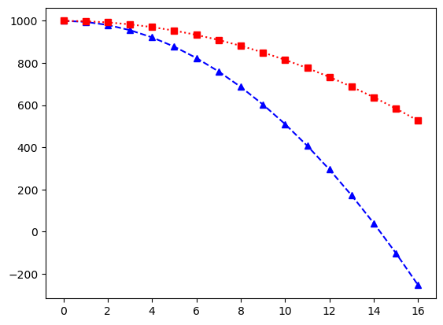

```python
plt.plot(t_list, y_Earth_list, 'b^--')
plt.plot(t_list, y_Mars_list, 'rs:')
```

### Labeling plots

When graphing data, we should (almost) always include:

- A title, which can be added using the `title` function.
- Axis labels, which can be added using the `xlabel` and `ylabel` functions.

When plotting several curves in a single figure, we should also label the curves and include a legend. When calling the `plot` function, we can use the `label` keyword argument to give a label to the data being plotted. We can then use the `legend` function to add a legend to the figure.

Note: Titles and labels can include LaTeX.

**Exercise:** Replicate the previous plot and add appropriate labels.

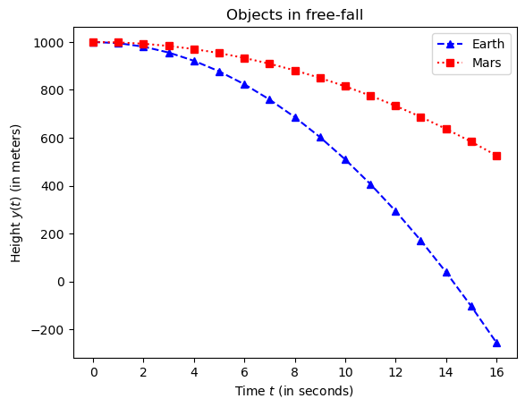

```python
plt.plot(t_list, y_Earth_list, 'b^--', label='Earth')
plt.plot(t_list, y_Mars_list, 'rs:', label='Mars')

plt.xlabel('Time $t$ (in seconds)')
plt.ylabel('Height $y(t)$ (in meters)')
plt.title('Objects in free-fall')

plt.legend()
```

### Further tweaks: axis limits, grid lines

We can use `plt.grid()` to add grid lines to the interior of the plot.

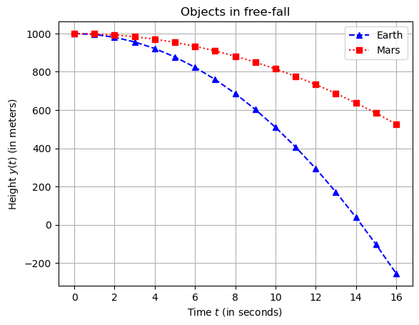

```python
plt.plot(t_list, y_Earth_list, 'b^--', label='Earth')
plt.plot(t_list, y_Mars_list, 'rs:', label='Mars')

plt.xlabel('Time $t$ (in seconds)')
plt.ylabel('Height $y(t)$ (in meters)')
plt.title('Objects in free-fall')

plt.legend()

plt.grid()
```

We can change the horizontal and vertical limits using the `plt.xlim` and `plt.ylim` function.

**Exercise:** Modify the horizontal and vertical limits to approximate how long it takes for the object to hit the ground (i.e. reach $y(t)=0$) on Earth.

```
(-25.0, 25.0)
```

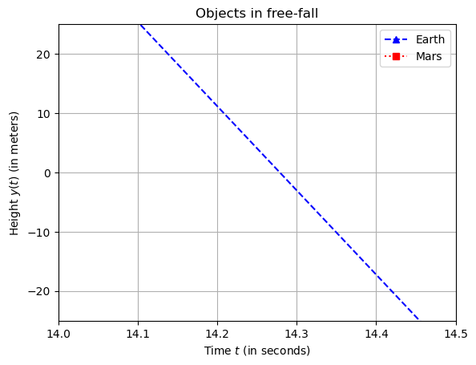

```python
plt.plot(t_list, y_Earth_list, 'b^--', label='Earth')
plt.plot(t_list, y_Mars_list, 'rs:', label='Mars')

plt.xlabel('Time $t$ (in seconds)')
plt.ylabel('Height $y(t)$ (in meters)')
plt.title('Objects in free-fall')

plt.legend()

plt.grid()

plt.xlim(14,14.5)
plt.ylim(-25,25)
```

## Generating a list of equally spaced data points

In the plots above, we generated our list of $t$ values by selecting only integer values in a given range. Suppose that we want to evaluate the function $y(t)$ on a more densely-packed list of $t$-values. Can we come up with a formulaic method for constructing such a list of $t$-values to be plugged in?

To do this, we can divide an interval $[a,b]$ of $t$ values up into $N$ equally spaced sub-intervals. In total, there will be $N+1$ points that will serve as the endpoints of these $N$ sub-intervals. That is, we have $$a = t_0 < t_1 < t_2 < \dots < t_N = b,$$ where each $t_i$ is an endpoint of one of the sub-intervals and the sub-interval width $\Delta t$ between $t_i$ and $t_{i+1}$ is constant.

Given this setup, what is the width $\Delta t$ of each sub-interval, and what are each of the endpoints $t_i$ for $i = 0, 1, 2, \dots, N$?

```python
a = 0
b = 16
N = 1000
dt = (b - a)/N

t_list = []
for i in range(N+1):
    t_list.append(a + i*dt)
```

```python
a = 0
b = 16
N = 1000
dt = (b - a)/N

t_list = [(a + i*dt) for i in range(N+1)]
```

```python
print(t_list[:10])
```

```
[0.0, 0.016, 0.032, 0.048, 0.064, 0.08, 0.096, 0.112, 0.128, 0.14400000000000002]
```

**Exercise:** Modify your code above to generate a list of $1000$ equally spaced $t$-values between $t=0$ and $t=16$. Then plot the trajectories on Earth and Mars for an object starting at an initial height of $1000$m with an initial velocity of $20$ m/s.

```python
y0 = 1000
v0 = 20

y_Earth_list = [y(t, y0=y0, v0=v0, g=g_Earth) for t in t_list]
y_Mars_list = [y(t, y0=y0, v0=v0, g=g_Mars) for t in t_list]
```

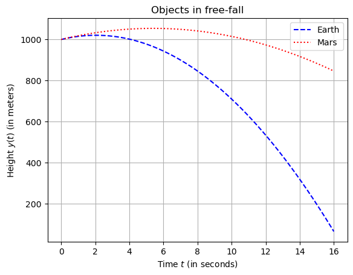

```python
plt.plot(t_list, y_Earth_list, 'b--', label='Earth')
plt.plot(t_list, y_Mars_list, 'r:', label='Mars')

plt.xlabel('Time $t$ (in seconds)')
plt.ylabel('Height $y(t)$ (in meters)')
plt.title('Objects in free-fall')

plt.legend()

plt.grid()
```

It is not hard to imagine that this is something that we will want to do very often (e.g. anytime that we are trying to plot a continuous function). We will soon see a much easier way to accomplish this same goal.

## [Project 2: Pythagorean triples](https://jllottes.github.io/Projects/pythagorean_triples/pythagorean_triples.html)

The second project deals with exploring triples of integers known as *Pythagorean triples* (see [project page](https://jllottes.github.io/Projects/pythagorean_triples/pythagorean_triples.html) for details). We already have all of the Python tools necessary to find and explore these triples, and we will continue discussing using Matplotlib to visualize them.

One of the first tasks that we will need to tackle is to identify when we have a Pythagorean triple. To do so, it will be helpful if we can identify whether or not a given integer $n$ is a perfect square. That is, we want to determine if $n = m^2$ for some integer $m$.

**Exercise:** Write a function `is_square` that takes in an integer `n` and returns `True` if `n` is a perfect square and `False` otherwise.

```python
25**(.5)
```

```
5.0
```

```python
from math import sqrt
```

```python
sqrt(25)
```

```
5.0
```

```python
def is_square(n):
    sqrt_n = sqrt(n)
    int_sqrt_n = int(sqrt_n)
    if sqrt_n == int_sqrt_n:
        return True
    else:
        return False
```

```python
def is_square(n):
    sqrt_n = sqrt(n)
    m = round(sqrt_n)
    if m**2 == n:
        return True
    else:
        return False
```

**Exercise:** Write a function `is_ptriple` that takes in a triple of integers $(a,b,c)$ and returns `True` if the triple is a Pythagorean triple, and `False` otherwise.

**Exercise:** Write a function `is_pdouble` that takes in a double of integers $(a,b)$ and returns `True` if the double is a Pythagorean double, and `False` otherwise.

```python
ptriples = [[3, 4, 5],
[4, 3, 5],
[5, 12, 13],
[6, 8, 10],
[8, 6, 10],
[8, 15, 17],
[9, 12, 15],
[12, 5, 13],
[12, 9, 15],
[12, 16, 20],
[15, 8, 17],
[15, 20, 25],
[16, 12, 20],
[20, 15, 25]]
```

```python
a_list = [ptriple[0] for ptriple in ptriples]
b_list = [ptriple[1] for ptriple in ptriples]
```

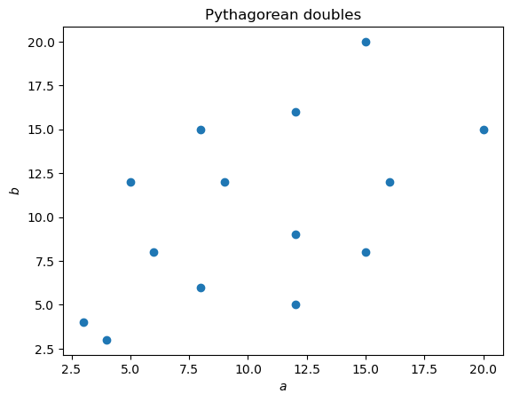

```python
plt.plot(a_list, b_list, 'o')
plt.xlabel('$a$')
plt.ylabel('$b$')
plt.title('Pythagorean doubles')
```